# Simulations for `norm_bqicu_sim.R`

# System setup

```r
R <- list.files(path = "./simulations/R", pattern = "*.R", full.names = TRUE)
sapply(R, source, .GlobalEnv)
source("./simulations/explore/norm_bqicu_sim_data2_sim/sim_data2.R")
library(knitr)
library(kableExtra)
```

# Setting

## Data

Following Wang *et al.* (2012) with one-hundred replications, the correlated normal responses are generated from the model
$$y_{ij} = \mathbf{X}_{ij}^{\top}\boldsymbol{\beta}
+ \varepsilon_{ij},$$
where $i = 1, \ldots, 200,$ $j = 1, \ldots, 4,$ $\mathbf{X}_{ij} = (x_{ij, 1}, \ldots, x_{ij, 6})^{\top},$ and $\boldsymbol{\beta} = (2.0, 3.0, 0.5, 0.0, 0.0, 0.0)^{\top}.$

- For the covariates,
  - $x_{ij,1}$ was generated from the Bernoulli(0.5) distribution, and
  - $x_{ij,2}$ to $x_{ij,6}$ from $Uniform(j, j + 1)$ and $\log$-tranformed.
- The random errors $(\varepsilon_{i1}, \ldots, \varepsilon_{i4})^{\top}$ are generated from the multivariate normal distribution with marginal mean 0, marginal variance 1, and an exchangeable correlation matrix with $\rho = 0.5$.

## Best subsets

All of the $(2^6 - 1) \times 4 = 252$ the subsets of the fully saturated model were fit using either an independence, exchangeable, AR(1), or unstructured working correlation structures. Then, the models resulting in the minimum QIC, QICu, and BQICu value were selected as the best fitting models.

```r
nsims <- 100L
beta <- c(2.0, 3.0, 0.5, 0.0, 0.0, 0.0)
w <- which(beta != 0)
l <- length(w)
```

# Results

The simulations results are stored in:

```r
load(
  file = paste0(
    "./simulations/explore/",
    "norm_bqicu_sim_data2_sim/norm_bqicu_sim_data2_sim.RData"
  )
)
```

and provide an overall look at the performane of QIC, QICu, and BQICu. Additionally, these results are by-product of an updated version of the `sim_data` function. The development version of this function is stored in the `simulations/explore` directory.

```r
sim_data2
```

```
## function (N, n, beta, family = stats::gaussian(), rho = 0.5,
##     corstr = "exchangeable", zvar = 1, zcor = NULL)
## {
##     if (!(N%%1 == 0) || !(n%%1 == 0)) {
##         stop("N and n must be of integer type.")
##     }
##     if (length(beta) == 0) {
##         stop("beta must be at least a length of 1.")
##     }
##     if ((rho < -1) || (rho > 1)) {
##         stop("rho must be between -1 and 1.")
##     }
##     if (zvar < 0 || length(zvar) > 1) {
##         stop("zvar must be a scalar greater than 0.")
##     }
##     if ("family" != class(family)) {
##         stop("family must be a family object produce by stats::family.")
##     }
##     if (!(corstr %in% c("exchangeable", "ar1", "independence",
##         "userdefined"))) {
##         stop(paste0("corstr must be one of the following: ",
##             "exchangeable, ar1, independence, userdefined."))
##     }
##     if (corstr == "userdefined") {
##         if (is.null(zcor)) {
##             stop("zcor must be specified if corstr = userdefined")
##         }
##         if (!is.null(zcor) && !is.matrix(zcor)) {
##             stop("zcor must be a square p.s.d matrix")
##         }
##         if ((dim(zcor)[1] != n) || (dim(zcor)[2] != n)) {
##             stop("zcor must be a square matrix of size n x n.")
##         }
##     }
##     p <- length(beta)
##     tmpts <- rep(1:n, times = N)
##     X <- matrix(NA, nrow = N * n, ncol = p)
##     X[, 1] <- rbinom(N * n, 1, 0.5)
##     for (j in 2:p) {
##         X[, j] <- log(stats::runif(length(tmpts), tmpts, tmpts +
```

[output cut: 24 more lines]

```
##     }
##     else if (fam$family == "poisson") {
##         y <- stats::rpois(N * n, eta)
##     }
##     else if (fam$family == "binomial") {
##         y <- stats::rbinom(N * n, 1, eta)
##     }
##     else if (fam$family == "Gamma") {
##         y <- stats::rgamma(N * n, eta)
##     }
##     colnames(X) <- paste0("X", seq_len(p))
##     names(beta) <- paste0("X", seq_len(p))
##     return(structure(list(y = y, X = X, id = id, beta = beta),
##         class = "sim.data"))
## }
```

## Information criterions across the simulations

Now for each of the models with the minimum QIC, QICu and BQICu, the information criteria values will be broken into their parts to see what is impacting the selection process. Additionally, this provides a look at the stability of the information criterions across the simulations. QICu and BQICu have the same goodness-of-fit term (GOF) as QIC (2001a)
$$GOF = -2 * \text{quasi-likelihood},$$
which assumes independence among the response to allow the use of the quasi-likelihood framework. The penalty term for QIC is $2tr\left(\widehat{\boldsymbol{\Omega}}_{I}\widehat{\mathbf{V}}_{R}\right)$. However, QICu and BQICu replace the penalty term of QIC with $2p$ and $\log(N)p,$ respectively, where $p$ is the number of parameters in the model.

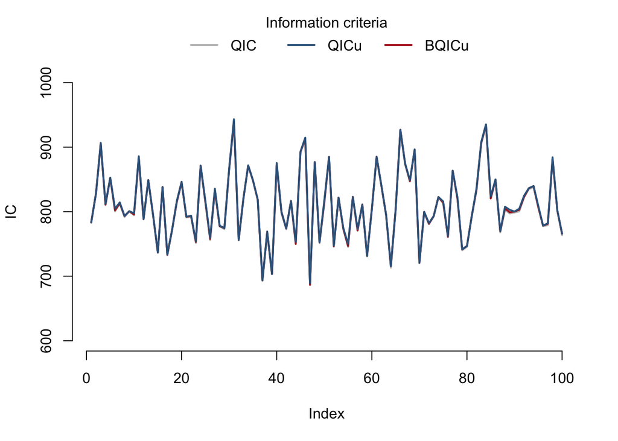

```r
q <- sapply(res_qic, function(x) {x$ic_min}, simplify = TRUE)
qu <- sapply(res_qicu, function(x) {x$ic_min}, simplify = TRUE)
bqu <- sapply(res_bqicu, function(x) {x$ic_min}, simplify = TRUE)

plot(
    x = seq_len(nsims), y = q,
    ylim = c(600, 1000),
    xlab = "Index", ylab = "IC",
    type = "l", lwd = 2, col = "gray",
    bty = "n",
)
lines(
    x = seq_len(nsims), y = qu,
    col = "firebrick", lwd = 2
)
lines(
    x = seq_len(nsims), y = bqu,
    col = "steelblue4", lwd = 2
)
legend_top(
    legend = c("QIC", "QICu", "BQICu"),
    col = c("gray", "steelblue4", "firebrick"),
    lwd = 2, lty = 1, title = "Information criteria"
)
```

### Goodness-of-fit

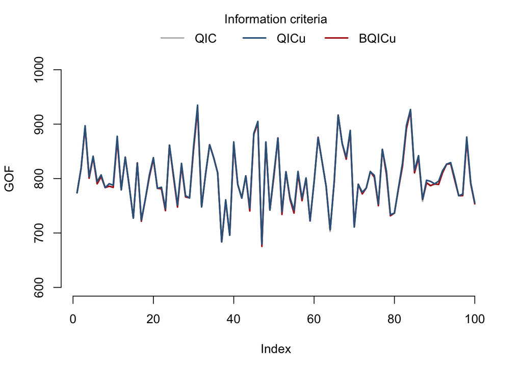

```r
gf_q <- rep(NA, nsims)
gf_qu <- rep(NA, nsims)
gf_bqu <- rep(NA, nsims)
for (k in seq_len(nsims)) {
    w_q <- res_qic[[k]]$min
    w_qu <- res_qicu[[k]]$min
    w_bqu <- res_bqicu[[k]]$min
    gf_q[k] <- res_qic[[k]]$gof[w_q]
    gf_qu[k] <- res_qicu[[k]]$gof[w_qu]
    gf_bqu[k] <- res_bqicu[[k]]$gof[w_bqu]
}

plot(
    x = seq_len(nsims), y = gf_q,
    ylim = c(600, 1000),
    xlab = "Index", ylab = "GOF",
    type = "l", lwd = 2, col = "gray",
    bty = "n"
)
lines(
    x = seq_len(nsims), y = gf_qu,
    col = "firebrick", lwd = 2
)
lines(
    x = seq_len(nsims), y = gf_bqu,
    col = "steelblue4", lwd = 2
)
legend_top(
    legend = c("QIC", "QICu", "BQICu"),
    col = c("gray", "steelblue4", "firebrick"),
    lwd = 2, lty = 1, title = "Information criteria"
)
```

### Penalty

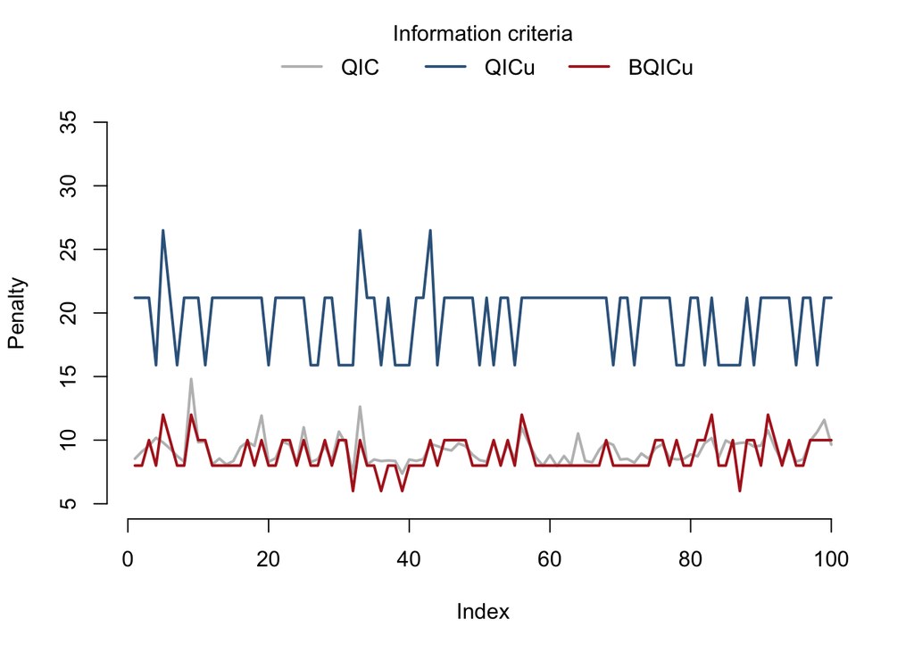

```r
penalty_q <- rep(NA, nsims)
penalty_qu <- rep(NA, nsims)
penalty_bqu <- rep(NA, nsims)
for (k in seq_len(nsims)) {
    w_q <- res_qic[[k]]$min
    w_qu <- res_qicu[[k]]$min
    w_bqu <- res_bqicu[[k]]$min
    penalty_q[k] <- res_qic[[k]]$penalty[w_q]
    penalty_qu[k] <- res_qicu[[k]]$penalty[w_qu]
    penalty_bqu[k] <- res_bqicu[[k]]$penalty[w_bqu]
}

plot(
    x = seq_len(nsims), y = penalty_q,
    ylim = c(5, 35),
    xlab = "Index", ylab = "Penalty",
    type = "l", lwd = 2, col = "gray",
    bty = "n"
)
lines(
    x = seq_len(nsims), y = penalty_qu,
    col = "firebrick", lwd = 2
)
lines(
    x = seq_len(nsims), y = penalty_bqu,
    col = "steelblue4", lwd = 2
)
legend_top(
    legend = c("QIC", "QICu", "BQICu"),
    col = c("gray", "steelblue4", "firebrick"),
    lwd = 2, lty = 1, title = "Information criteria"
)
```

## Structure selection based on IC

### Mean

For measuring the overall performance of selecting the mean structure, a function will be created called `look` that reports the number of models, where

- the number of features selected is less than the number of non-zero coefficients in the generating model (`under`),
- only the non-zero features from the generating model were selected (`exact`),
- the number of features selected matches the number of non-zero coefficients in the generating model; however, at least one of the selected features is NOT one of the non-zero effects in the generating model (`mis`),
- the number of features selected is greated than the number of non-zero coefficients in the generating model (`over`), and
- the number of features selected is greated than the number of non-zero coefficients in the generating model and includes all the non-zero effects (`over_inc`).

```r
# creating a function to generate a look at the simulation results
look <- function(x) {
    under <- 0
    exact <- 0
    mis <- 0
    over <- 0
    over_inc <- 0
    for (k in seq_along(x)) {
        under <- under + (length(x[[k]]$vars) < l)
        exact <- exact + identical(x[[k]]$vars, w)
        mis <- mis + (!identical(x[[k]]$vars, w) & (length(x[[k]]$vars) == l))
        over <- over + (length(x[[k]]$vars) > l)
        over_inc <- over_inc + ((length(x[[k]]$vars) > l) & all(w %in% x[[k]]$vars))
    }
    return(
        data.frame(
            under = under, exact = exact,
            mis = mis, over = over,
            over_inc = over_inc
        )
    )
}
```

Using the `look` function, we have the following summary measures from the simulation set, where the models resulting in the minimum QIC, QICu, and BQICu values were selected as the best fitting models.

```r
data.frame(
    ic = c("QIC", "QICu", "BQICu"),
    dplyr::bind_rows(look(res_qic), look(res_qicu), look(res_bqicu))
)
```

```
##      ic under exact mis over over_inc
## 1   QIC     3    48   5   44       41
## 2  QICu     4    51   4   41       38
## 3 BQICu    29    59   9    3        3
```

### Correlation

Now for measuring the overall performance of selecting the correlation structure, the table below presents the number of models, where the correlation structure selected from the best subsets was AR(1) (`ar1`), exchangeable (`exchangeable`), independence (`independence`), and unstructured (`unstructured`). Note that proper selection of the mean structure is not needed to select the correlation structure correctly.

```r
corstr_q <- sapply(res_qic, function(x) {x$corstr_min}, simplify = TRUE)
corstr_qu <- sapply(res_qicu, function(x) {x$corstr_min}, simplify = TRUE)
corstr_bqu <- sapply(res_bqicu, function(x) {x$corstr_min}, simplify = TRUE)

corstr_count <- function(x) {
    count_indp <- 0
    count_cs <- 0
    count_ar1 <- 0
    count_un <- 0
    for (i in seq_along(x)) {
        count_indp <- count_indp + (x[i] == "independence")
        count_cs <- count_cs + (x[i] == "exchangeable")
        count_ar1 <- count_ar1 + (x[i] == "ar1")
        count_un <- count_un + (x[i] == "unstructured")
    }
    temp <- data.frame(
        indpendenence = count_indp, exchangeable = count_cs,
        ar1 = count_ar1, unstructured = count_un
    )
    return(temp)
}

data.frame(
    ic = c("QIC", "QICu", "BQICu"),
    dplyr::bind_rows(
        corstr_count(corstr_q),
        corstr_count(corstr_qu),
        corstr_count(corstr_bqu)
    )
)
```

```
##      ic indpendenence exchangeable ar1 unstructured
## 1   QIC            10           44   2           44
## 2  QICu           100            0   0            0
## 3 BQICu           100            0   0            0
```

### Joint

Finally, a joint selection table will provide a look at selecting the working correlation structure (`corstr`) and the mean structure appropriately. The column names listed of `under`, `exact`, `mis`, `over` and `over_inc` represent the same measures discussed previously. This table will also present results based on the information criteria used.

```r
joint <- function(x) {
    p <- function(y) {
        if (length(y) == 0) {
            return(data.frame(under = 0, exact = 0, mis = 0, over = 0, over_inc = 0))
        } else {
            return(look(x = y))
        }
    }

    independence <- x[sapply(x, function(x) {x$corstr_min == "independence"}, simplify = TRUE)]
    exchangeable <- x[sapply(x, function(x) {x$corstr_min == "exchangeable"}, simplify = TRUE)]
    ar1 <- x[sapply(x, function(x) {x$corstr_min == "ar1"}, simplify = TRUE)]
    un <- x[sapply(x, function(x) {x$corstr_min == "unstructured"}, simplify = TRUE)]

    ip <- p(independence)
    ep <- p(exchangeable)
    ap <- p(ar1)
    up <- p(un)

    return(dplyr::bind_rows(ip, ep, ap, up))
}

data.frame(
    ic = rep(c("QIC", "", "QICu", "", "BQICu", ""), rep(c(1, 3), 3)),
    corstr = rep(c("Independence", "Exchangeable", "AR(1)", "Unstructured"), 3),
    dplyr::bind_rows(joint(res_qic), joint(res_qicu), joint(res_bqicu))
)
```

```
##       ic       corstr under exact mis over over_inc
## 1    QIC Independence     2     4   1    3        3
## 2        Exchangeable     1    17   3   23       23
## 3               AR(1)     0     1   0    1        1
## 4        Unstructured     0    26   1   17       14
## 5   QICu Independence     4    51   4   41       38
## 6        Exchangeable     0     0   0    0        0
## 7               AR(1)     0     0   0    0        0
## 8        Unstructured     0     0   0    0        0
## 9  BQICu Independence    29    59   9    3        3
## 10       Exchangeable     0     0   0    0        0
## 11              AR(1)     0     0   0    0        0
## 12       Unstructured     0     0   0    0        0
```